# Ambient Noise Seismology: From Theory to Practice

## 11.2 Transdimensional Bayesian Inversion with BayHunter

**BayHunter** (Dreiling & Tilmann, 2019) is a Python tool for **transdimensional Bayesian inversion** of surface-wave dispersion curves (and optionally receiver functions) to recover 1D $V_s(z)$ profiles.

### What Makes It "Transdimensional"?

In a standard inversion, you must **choose** the number of layers beforehand. BayHunter lets the **data decide** by allowing the MCMC sampler to:

- **Add a layer** (birth step): split one layer into two
- **Remove a layer** (death step): merge two adjacent layers
- **Change a layer** (perturbation step): modify thickness, $V_s$, or $V_p/V_s$
- **Change noise** (noise step): update the noise hyperparameter

This is implemented via **Reversible-Jump MCMC** (Green, 1995), which generalizes the Metropolis-Hastings algorithm to variable-dimension parameter spaces.

### The BayHunter Model

A 1D Earth model in BayHunter consists of:

$$\mathbf{m} = \{n, h_1, V_{s,1}, h_2, V_{s,2}, \ldots, h_n, V_{s,n}, V_p/V_s\}$$

where:

- $n$ = number of layers (free parameter, e.g., 1–10)
- $h_i$ = thickness of layer $i$
- $V_{s,i}$ = shear velocity of layer $i$
- $V_p/V_s$ = compressional-to-shear velocity ratio (1.4–2.1)

### Prior Distributions

BayHunter uses uniform priors on all parameters:

| Parameter | Typical Prior Range |
| --- | --- |
| $V_s$ | 0.5–4.0 km/s |
| $V_p/V_s$ | 1.4–2.1 |
| Number of layers | 1–10 (or more) |
| Maximum depth | User-defined (e.g., 2 km for near-surface) |
| Minimum layer thickness | e.g., 0.1 km |

### The MCMC Workflow

```
1. Initialize: random model with n layers
2. For each iteration:
   a. Randomly choose a perturbation type:
      - Change Vs in one layer
      - Change layer thickness
      - Birth (add a layer)
      - Death (remove a layer)
      - Change Vp/Vs ratio
      - Change noise parameter
   b. Compute forward model: theoretical dispersion curve
   c. Compute likelihood: p(d|m) = exp(-Φ/2)
      where Φ = (d_obs - d_pred)^T C_d^{-1} (d_obs - d_pred)
   d. Accept/reject via Metropolis-Hastings criterion
3. After burn-in: collect accepted models as posterior samples
4. Statistics: median, mean, mode, standard deviation of Vs(z)
```

### Convergence Diagnostics

BayHunter runs multiple chains in parallel and checks convergence by:

- Monitoring the **log-likelihood** evolution (should stabilize)
- Checking the **acceptance rate** (target: 40–45%)
- Detecting **outlier chains** (chains with likelihood deviating > $k \times 100\%$ from the best chain's median)

### From 1D Profiles to 3D Model

The complete workflow from ambient noise data to a 3D model is:

```
Cross-correlations → FTAN → Dispersion curves
                         ↓
              2D Tomography (Module 10)
         (one velocity map per period)
                         ↓
         Extract local dispersion curve
          at each grid point (pixel)
                         ↓
           Depth Inversion (Module 11)
         BayHunter at each grid point
                         ↓
              3D Vs(x, y, z) model
```

This is the approach used in `codes/2Dbayes/create_observed_depth_inv.py`, which:

1. Reads the 2D tomography results for all periods
2. At each grid point, extracts the velocity at each period → local dispersion curve
3. Saves these dispersion curves as input files for BayHunter
4. BayHunter is then run (in parallel on a cluster) at each grid point

```
True model:
  h=0.3 km, Vs=0.8 km/s
  h=0.5 km, Vs=1.5 km/s
  h=0.7 km, Vs=2.2 km/s
  h=half-space, Vs=3.0 km/s
Observed periods: [0.3 0.5 0.7 1.  1.5 2.  3.  4.  5. ]
Observed velocities: [0.756 0.901 1.065 1.183 1.509 1.643 2.111 2.319 2.474]

MCMC complete: 9901/15000 accepted (66.0%)
Posterior samples: 2000
```

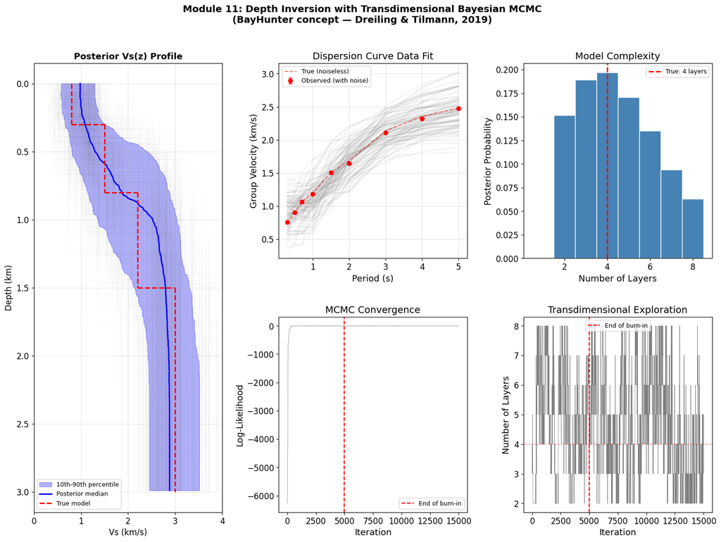

```
Key observations:
• The posterior median recovers the main features of the true model
• The 10th-90th percentile range shows where the model is well/poorly constrained
• The histogram of layer numbers peaks near the true value (4 layers)
• The log-likelihood stabilizes after burn-in — the chain has converged
• Deeper layers have wider uncertainty (less sensitivity at depth)

BayHunter in practice (codes/bayhunter_3D/):
• Input: dispersion curve files (period, group_velocity)
• Config: config.ini sets priors (vs, vpvs, layers, depth ranges)
• Run: python bayhunter_1input.py disp_file.dat (parallelized via SLURM)
• Output: posterior Vs(z) profiles, convergence plots, interface histograms
• For 3D: run BayHunter at each grid point from the 2D tomography maps
```

## 11.3 BayHunter Code Walkthrough

### Configuration (`config.ini`)

```
[modelpriors]
vpvs = 1.4, 2.1        # Vp/Vs ratio range
layers = 1, 10          # Min/max number of layers
vs = 0.5, 4             # Vs range (km/s)
z = 0, 2                # Depth range (km)
swdnoise_sigma = 1e-7, 0.5  # Surface wave noise range

[initparams]
nchains = 50            # Parallel MCMC chains
iter_burnin = (2048 * 100)   # ~200k burn-in iterations
iter_main = (2048 * 50)      # ~100k main phase iterations
propdist = 0.015, 0.015, 0.015, 0.005, 0.005  # Proposal step sizes
acceptance = 40, 45     # Target acceptance rate (%)
thickmin = 0.1          # Minimum layer thickness (km)
```

### Running BayHunter (`bayhunter_1input.py`)

```
from BayHunter import Targets, MCMC_Optimizer, utils, PlotFromStorage, ModelMatrix

# 1. Load observed dispersion curve
xsw, ysw = np.loadtxt('disp_file.dat').T  # period, group_velocity

# 2. Define targets (can combine group + phase + receiver functions)
target1 = Targets.RayleighDispersionGroup(xsw, ysw)
target2 = Targets.RayleighDispersionPhase(xsw_ph, ysw_ph)  # optional
targets = Targets.JointTarget(targets=[target1, target2])

# 3. Run MCMC inversion
optimizer = MCMC_Optimizer(targets, initparams=initparams, priors=priors)
optimizer.mp_inversion(nthreads=50)  # 50 parallel chains

# 4. Save results and plots
obj = PlotFromStorage(configfile)
obj.save_final_distribution(maxmodels=1000000, dev=5)  # reject outlier chains
obj.save_plots(depint=0.01)  # posterior profiles at 10m resolution

# 5. Extract posterior statistics
models = np.load('data/c_models.npy')
singlemodels = ModelMatrix.get_singlemodels(models, dep_int=np.arange(0, 2, 0.01))
vs_median, dep = singlemodels['median']
vs_mean, dep = singlemodels['mean']
```

### Building the 3D Model

The script `create_observed_depth_inv.py` in `codes/2Dbayes/` automates the pipeline:

```
# For each grid point from the 2D tomography:
for nx in grid_points:
    # Extract velocity at all periods → local dispersion curve
    vels = ALL_VELS[:, nx]  # velocities from all period maps
    times = TIMES           # corresponding periods

    # Apply Gaussian smoothing
    vg_smooth = gaussian_filter1d(vels, sigma=1)

    # Save as BayHunter input file
    np.savetxt(f'disp_{lat}_{lon}.dat',
               np.column_stack((times, vg_smooth)))
```

Then BayHunter is run on each file via SLURM array jobs:

```
sbatch --array=1-500 run_array.sh  # One job per grid point
```

The final 3D model is assembled by `extract.py`, which reads each BayHunter output and combines them into a (lon, lat, depth, Vs) volume.

### Installation

```
pip install BayHunter  # or from GitHub: pip install git+https://github.com/jenndrei/BayHunter
```

GitHub: https://github.com/jenndrei/BayHunter

# Module 12: Seismic Interferometry Principles

## 9.1 What is Seismic Interferometry?

Seismic interferometry is the broader principle that underlies ambient noise tomography. It refers to the **extraction of deterministic information** (impulse responses, Green's functions) from the **interference of seismic waves** (Campillo & Roux, 2015; Wapenaar, 2004).

### Historical Development

| Year | Contribution | Reference |
| --- | --- | --- |
| 1957 | Spatial autocorrelation (SPAC) method | Aki (1957) |
| 1968 | Daylight imaging conjecture | Claerbout (1968) |
| 2001 | Green's function from diffuse field correlations | Lobkis & Weaver (2001) |
| 2003 | Coda wave cross-correlation in seismology | Campillo & Paul (2003) |
| 2004 | Ambient noise surface wave tomography | Shapiro & Campillo (2004) |
| 2004 | Elastodynamic Green's function retrieval | Wapenaar (2004) |
| 2004 | Green's function from coda wave correlations | Snieder (2004) |
| 2006 | Passive image interferometry for monitoring | Sens-Schoenfelder & Wegler (2006) |

> *"The daylight imaging method was pioneered by Claerbout (1968), who proposed the conjecture stating that the cross-correlation of two daylight traces at surface locations A and B is equivalent to a reflection trace at B generated by a source at A."* -- Campillo & Roux (2015)

## 9.2 Types of Seismic Interferometry

### 9.2.1 Cross-Correlation Type

$$G(A,B) \propto \int_{\partial V} G(A,S) \star G(B,S) \, dS$$

The Green's function between A and B is retrieved by cross-correlating recordings at A and B from sources on a boundary $\partial V$.

### 9.2.2 Deconvolution Type

$$G(A,B) \propto \frac{U_A(\omega)}{U_B(\omega)}$$

The Green's function is retrieved by deconvolving the recording at one station by the other. This is useful when source properties are different at the two receivers (Jiang & Denolle, 2020, Eq. 3).

### 9.2.3 Cross-Coherence Type

$$G(A,B) \propto \frac{U_A^*(\omega) U_B(\omega)}{|U_A(\omega)| |U_B(\omega)|}$$

A normalized version that is equivalent to spectral whitening + cross-correlation (Prieto et al., 2009; Jiang & Denolle, 2020).

## 9.3 Requirements for Green's Function Retrieval

For the cross-correlation to converge to the true Green's function, several conditions should ideally be met (Campillo & Roux, 2015):

1. **Diffuse wavefield**: The noise sources should be distributed isotropically (or the scattering should create an effectively diffuse field)
2. **Sufficient recording duration**: Long time series allow more noise sources to contribute
3. **Equipartition**: Equal energy in all wave modes and propagation directions

### Practical Limitations (Campillo & Roux, 2015, Section 1.12.5)

- **Partial focusing**: Non-uniform source distribution leads to biased Green's functions
- **Amplitude information**: Only reliable when source distribution is uniform
- **Travel time measurements**: More robust than amplitude, even with imperfect source distribution
- **Scattering**: Helps redistribute energy and improve Green's function reconstruction

[output not shown]

[figure not shown]

# Module 13: Seismic Velocity Changes (dv/v) Monitoring

## 10.1 The Principle of Noise-Based Monitoring

One of the most powerful applications of ambient noise is the **continuous monitoring of seismic velocity changes** in the subsurface. This approach was pioneered by **Sens-Schoenfelder & Wegler (2006)** and has since been applied extensively to volcanoes, fault zones, and other geological settings.

> *"Sens-Schoenfelder and Wegler (2006) were the first to propose the consideration of daily cross-correlations of noise as repetitive in time Green's functions, which can be used to assess seismic velocity temporal changes."* -- Brenguier et al. (2016)

### The Concept (Brenguier et al., 2016, Fig. 1)

1. Compute daily noise cross-correlations between a pair of stations
2. Compare each daily cross-correlation with a **reference** (long-term average)
3. Measure the **time shift** $\delta t$ in the **coda** (late arrivals) of the cross-correlation
4. The relative velocity change is: $\frac{\delta v}{v} = -\frac{\delta t}{t}$

### Why the Coda?

The **coda** (late-arriving scattered waves) is particularly sensitive to velocity changes because:

- Coda waves have traveled **long distances** through the medium (via multiple scattering)
- Small velocity changes accumulate over the long path lengths
- The coda is **remarkably stable** between repeated measurements
- Precision of $\delta v/v$ can reach $10^{-5}$ (0.001%) — detecting velocity changes of 0.02 m/s on a 2000 m/s background (Brenguier et al., 2016)

## 10.2 Measurement Methods

### Stretching Technique

The effect of a global velocity change $\epsilon$ is to deform the time axis by $t' = t(1 - \epsilon)$. The stretching technique (Lobkis & Weaver, 2003; Sens-Schoenfelder & Wegler, 2006):

1. Stretch the current cross-correlation by various factors $\epsilon$
2. Find the $\epsilon_0$ that **maximizes the cross-correlation coefficient** with the reference
3. $\epsilon_0 = \delta v / v$

### Moving-Window Cross-Spectral Analysis (MWCSA)

Proposed by Poupinet et al. (1984) and Snieder et al. (2002):

1. Measure $\delta t$ in moving windows along the coda
2. Fit a linear regression: $\delta t = -(\delta v/v) \cdot t$
3. The slope gives $\delta v/v$

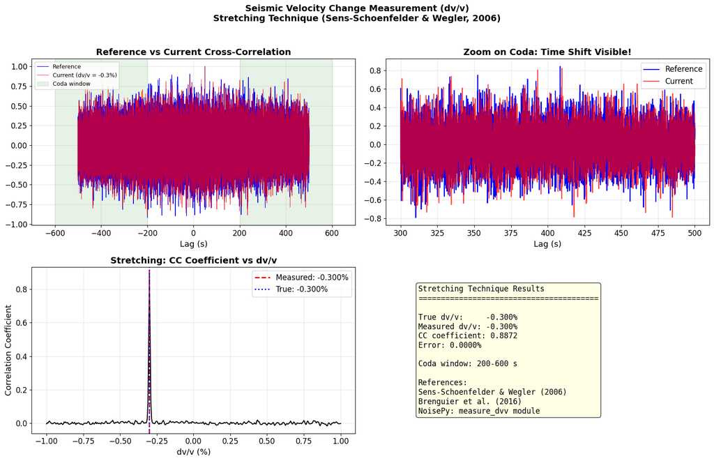

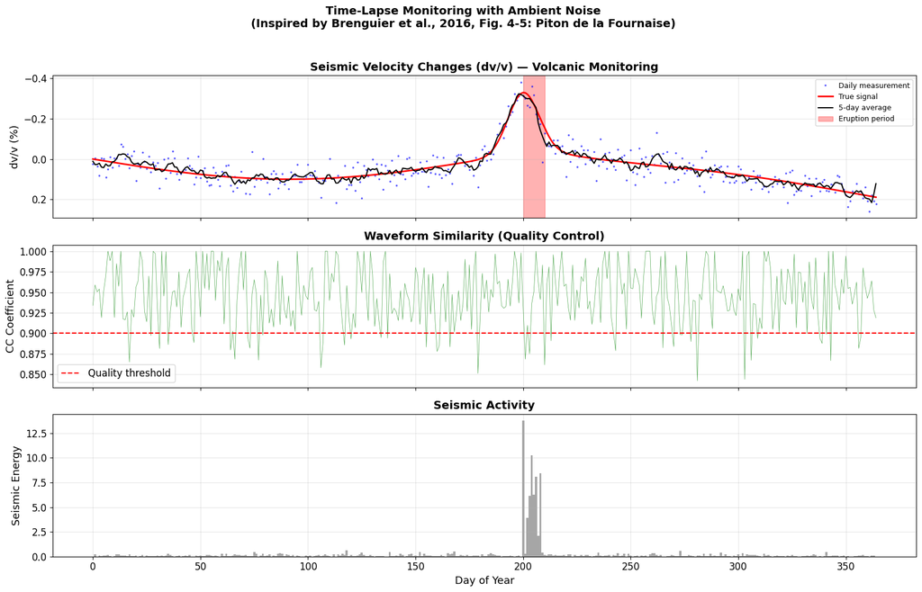

```
Key observations (cf. Brenguier et al., 2016):
1. Seasonal velocity variations (~0.1%) due to groundwater/thermal effects
2. Pre-eruptive velocity DECREASE: precursor signal days before eruption
3. Post-eruption velocity RECOVERY: slow return to normal
4. Precision of dv/v measurements can reach 10^-5 (Brenguier et al., 2016)
```

# Module 14: HVSR / MHVSR Method

## 13.1 The Horizontal-to-Vertical Spectral Ratio

The **Microtremor Horizontal-to-Vertical Spectral Ratio (MHVSR)** method is a single-station technique that uses ambient noise to characterize site effects (Molnar et al., 2022).

### History

- First proposed by **Nogoshi & Igarashi (1971)** in Japan
- Popularized internationally by **Nakamura (1989)**, who interpreted it as the S-wave transfer function
- Standardized by the **SESAME project** (2004) in Europe
- Comprehensive review by **Molnar et al. (2022)** covering theory, methods, and applications

### Definition

$$\text{HVSR}(f) = \frac{\sqrt{S_N^2(f) + S_E^2(f)}}{S_Z(f)} \qquad [\text{Molnar et al., 2022}]$$

where $S_N$, $S_E$, $S_Z$ are the Fourier Amplitude Spectra of the North, East, and Vertical components.

Alternatively, the **geometric mean** of horizontal spectra is used:

$$\text{HVSR}(f) = \frac{\sqrt{S_N(f) \cdot S_E(f)}}{S_Z(f)} \qquad [\text{Cox et al., 2020}]$$

### Site Resonance Frequency

The peak frequency $f_0$ of the HVSR corresponds to the **fundamental resonance frequency** of the site:

$$f_0 = \frac{V_s}{4H}$$

where $V_s$ is the shear-wave velocity of the soft layer and $H$ is its thickness.

### Applications

- **Site characterization**: Identifying the fundamental resonance frequency for seismic hazard assessment
- **Vs30 estimation**: Classifying sites per building codes (NBCC, Eurocode 8)
- **Bedrock depth mapping**: HVSR survey profiles to map depth to bedrock (Hunter & Crow, 2015)
- **Mineral exploration**: HVSR surveys for mapping sediment thickness over mineral deposits

## 13.2 Statistical Treatment: The Lognormal Distribution (Cox et al., 2020)

**Cox et al. (2020)** demonstrated that the resonance frequency $f_0$ follows a **lognormal distribution**, not a normal distribution. This has important implications for how HVSR results should be reported.

### Key Findings

- The **lognormal median** (LM) should be used instead of the arithmetic mean:

$$\text{LM}_{f_0} = \exp(\mu_{\ln f_0})$$

- The uncertainty should be expressed as the **lognormal standard deviation**:

$$\sigma_{\ln f_0} = \text{std}(\ln f_0)$$

### Frequency-Domain Window-Rejection Algorithm

**Cox et al. (2020)** proposed an iterative rejection algorithm:

1. Compute $f_0$ for each time window
2. Accept window $i$ only if:

$$f_{0,i} \in \left[\exp(\mu_{\ln f_0} - n \sigma_{\ln f_0}), \; \exp(\mu_{\ln f_0} + n \sigma_{\ln f_0})\right]$$

where $n = 2$ (analogous to 2-sigma rule but in log space).

3. Recompute statistics and repeat until convergence:
   - $|\Delta N_{\text{accepted}}| / N < 1\%$
   - $|\Delta \sigma_{\ln f_0}| < 0.01$

> **Software**: The `hvsrpy` Python package (Vantassel, 2020) implements this algorithm.

### SESAME Guidelines

The SESAME (2004) project established reliability criteria:

- **Minimum recording duration**: $T > 200 / f_0$ seconds
- **Minimum number of windows**: $n_w > 200 \cdot f_0 \cdot l_w$ where $l_w$ is window length
- **Window length**: At least 10 cycles of $f_0$, recommended $l_w > 10/f_0$
- **Peak amplitude**: $A_{\text{HVSR}}(f_0) > 2$ for a clear resonance peak

```
Downloading 3-component data for HVSR analysis...
3 Trace(s) in Stream:
IU.ANMO.00.BHZ | 2022-06-15T02:00:00.019538Z - 2022-06-15T02:59:59.994538Z | 40.0 Hz, 144000 samples
IU.ANMO.00.BH1 | 2022-06-15T02:00:00.019539Z - 2022-06-15T02:59:59.994539Z | 40.0 Hz, 144000 samples
IU.ANMO.00.BH2 | 2022-06-15T02:00:00.019539Z - 2022-06-15T02:59:59.994539Z | 40.0 Hz, 144000 samples
3 Trace(s) in Stream:
IU.ANMO.00.BHZ | 2022-06-15T02:00:00.019538Z - 2022-06-15T02:59:59.994538Z | 40.0 Hz, 144000 samples
IU.ANMO.00.BHN | 2022-06-15T02:00:00.019539Z - 2022-06-15T02:59:59.994539Z | 40.0 Hz, 144000 samples
IU.ANMO.00.BHE | 2022-06-15T02:00:00.019539Z - 2022-06-15T02:59:59.994539Z | 40.0 Hz, 144000 samples
```

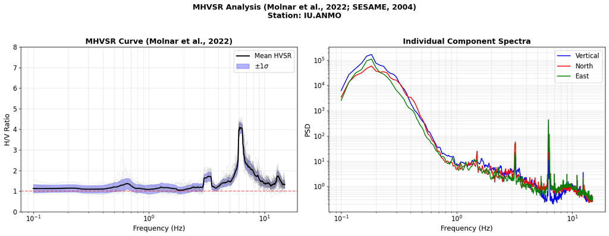

```
Fundamental resonance frequency (f0): 6.12 Hz
Corresponding period: 0.2 s

If Vs = 300 m/s, estimated sediment thickness h = Vs/(4*f0) = 12 m
```

# Module 15: NoisePy — Large-Scale Ambient Noise Processing

## 15.1 Overview

**NoisePy** (Jiang & Denolle, 2020) is a Python-based ambient noise processing package designed for large-scale seismological datasets. It handles the full pipeline from raw waveforms to stacked cross-correlations, parallelized with **MPI** for HPC clusters.

Our production workflow uses NoisePy in three sequential steps:

| Step | Script | Purpose | Input | Output |
| --- | --- | --- | --- | --- |
| **S0A** | `S0A_dowload_ASDF_MPI.py` | Download from FDSN | Network/station/time window | ASDF `.h5` files (time chunks) |
| **S0B** | `S0B_to_ASDF.py` | Convert local miniseed/SAC to ASDF | Raw `.miniseed` files | ASDF `.h5` files (time chunks) |
| **S1** | `S1_fft_cc_MPI.py` | FFT + cross-correlation | Clean ASDF `.h5` | CC `.h5` per time chunk |
| **S2** | `S2_stacking.py` | Stack all CCs per pair | CC `.h5` files | Final stacked `.h5` per pair |

Each step reads its parameters from a **YAML configuration file** and runs via `mpiexec`.

## 15.2 Step S0: Data Preparation

### S0A — Download from FDSN

`S0A_dowload_ASDF_MPI.py` downloads seismic data from FDSN web services (IRIS, ETH, etc.) and saves it in ASDF/HDF5 format. Key operations:

1. **Station discovery**: Either from a pre-compiled CSV list (`down_list: True`) or by querying the FDSN client within a geographic bounding box
2. **Memory estimation**: Checks that the data volume fits in `MAX_MEM` per MPI core
3. **MPI-parallel download**: Each MPI rank processes different time chunks (`inc_hours`)
4. **Preprocessing**: Removes gaps, instrument response, downsamples to `samp_freq`, trims to chunk length
5. **Output**: One ASDF `.h5` file per time chunk, containing all stations

#### S0A Configuration (`S0A_params.yaml`)

```
rootpath: '/path/to/project/'
direc: '/path/to/RAW_DATA'
dlist: '/path/to/station.txt'         # CSV with network,station,channel,lat,lon
client_name: 'ETH'                     # FDSN data center
down_list: False                       # True = use CSV list, False = query by region
lamin: 46.0                            # Bounding box for station search
lamax: 47.5
lomin: 7.0
lomax: 9.0
chan_list: ["BHE","BHN","BHZ"]         # Channels to download
ncomp: 3                              # Must match chan_list
net_list: ["CH"]                       # Networks
sta_list: ["*"]                        # Stations (wildcard = all)
start_date: "2019_04_11_0_0_0"
end_date: "2022_01_12_0_0_0"
inc_hours: 24                          # One file per day
samp_freq: 25                          # Target sampling rate (Hz)
rm_resp: 'inv'                         # Remove response using inventory
freqmin: 0.05                          # Pre-filter band (Hz)
freqmax: 14.5
cc_len: 1800                           # Used for memory estimation
step: 450
MAX_MEM: 3.0                           # Max memory per MPI core (GB)
```

### S0B — Convert Local Miniseed to ASDF

When data is already on disk (e.g., from nodal instruments like SmartSolo), `S0B_to_ASDF.py` converts raw miniseed files to NoisePy's ASDF format:

1. **File inventory**: Builds a timestamp catalog (`wiki_file`) mapping each miniseed file to its start/end time — this speeds up processing by 2–3 orders of magnitude
2. **Station matching**: Uses a CSV coordinates file with `network,station,channel,latitude,longitude`
3. **MPI-parallel conversion**: Each rank handles different time chunks
4. **Preprocessing**: Same pipeline as S0A (detrend, filter, optional response removal)

#### S0B Configuration (`S0B_params.yaml`)

```
rootpath: '/path/to/project/'
RAWDATA: '/path/to/miniseed_files/'
DATADIR: '/path/to/CLEAN_DATA_H5'     # Output directory
locations: '/path/to/coordinates.csv'   # Station coordinates
input_fmt: 'mseed'                     # 'mseed' or 'sac'
samp_freq: 25
stationxml: False                      # No XML needed if rm_resp='no'
rm_resp: 'no'                          # Or 'inv' with respdir
freqmin: 0.02
freqmax: 12
wiki_file: '/path/to/allfiles_time.csv'  # Pre-built file catalog
allfiles_path: '/path/to/*.miniseed'
messydata: True                        # Files not in daily subdirectories
ncomp: 3
start_date: '2024_04_02_0_0_0'
end_date: '2024_04_29_0_0_0'
inc_hours: 8                           # Chunk length (shorter for nodes)
cc_len: 300
step: 60
MAX_MEM: 10.0
```

## 15.3 Step S1: FFT and Cross-Correlation

`S1_fft_cc_MPI.py` is the core computation step. For each time chunk:

1. **Load ASDF** data for all stations in the chunk
2. **Cut into segments** of `cc_len` seconds with `step` overlap
3. **Noise processing** per segment:
   - `time_norm`: `'one_bit'` (sign normalization), `'rma'` (running mean), or `'no'`
   - `freq_norm`: `'rma'` (spectral whitening), `'phase_only'`, or `'no'`
   - For **coherency**: use `freq_norm='rma'`, `time_norm='no'`, `cc_method='xcorr'`
4. **FFT** all segments, store in memory as complex arrays
5. **Quality control**: Reject windows where amplitude exceeds `max_over_std` × median
6. **Cross-correlate** all station pairs (or auto-correlations if `acorr_only=True`)
7. **Sub-stacking**: If `substack=True`, pre-stack every `substack_len` seconds
8. **Output**: One ASDF `.h5` per time chunk with all CC pairs

#### S1 Configuration (`S1_params.yaml`)

```
CCFDIR: '/path/to/CCF_output'
DATADIR: '/path/to/CLEAN_DATA_H5'
input_fmt: 'h5'
freq_norm: 'rma'         # Spectral whitening method
time_norm: 'no'          # Time-domain normalization
cc_method: 'xcorr'       # 'xcorr', 'deconv', or coherency (see above)
acorr_only: False        # True for auto-correlations only
ncomp: 3
cc_len: 300              # Segment length for FFT (s)
step: 60                 # Overlap = cc_len - step (s)
smooth_N: 20             # Smoothing window for normalization (points)
maxlag: 60               # Max lag time to save (s)
substack: True
substack_len: 2400       # Pre-stack this many seconds
smoothspect_N: 20        # Spectrum smoothing window (points)
max_over_std: 100        # QC threshold
MAX_MEM: 20.0
```

**Important**: `samp_freq`, `freqmin`, `freqmax`, `start_date`, `end_date`, and `inc_hours` are automatically read from S0's `download_info.yaml`.

## 15.4 Step S2: Stacking and Rotation

`S2_stacking.py` assembles all time-chunk CCs for each station pair and produces the final stacked waveforms:

1. **Load all CC chunks** for each station pair across all time chunks
2. **Stack** using one or all methods:
   - `'linear'`: Simple mean
   - `'pws'`: Phase-weighted stacking
   - `'robust'`: Iteratively reweighted
   - `'nroot'`: Nth-root stacking
   - `'auto_covariance'`: Auto-covariance based
   - `'all'`: Run all methods and save each
3. **Rotation** (if `ncomp=3`): Rotate from E-N-Z to R-T-Z system using back-azimuth, producing 9 components (ZR, ZT, ZZ, RR, RT, RZ, TR, TT, TZ)
4. **Output**: One `.h5` file per station pair in `STACKDIR/NET.STA/`

#### S2 Configuration (`S2_params.yaml`)

```
CCFDIR: '/path/to/CCF_output'
STACKDIR: '/path/to/STACK_output'
locations: '/path/to/coordinates.csv'
keep_substack: False        # Keep individual sub-stacks
stack_method: 'all'         # 'linear','pws','robust','nroot','all'
ncomp: 3
enz_system_option: 1
overwrite: False
rotation: True              # E-N-Z → R-T-Z rotation
correction: False           # Orientation correction
MAX_MEM: 20.0
```

## 15.5 Running on HPC with SLURM

All three steps are launched via MPI on a SLURM cluster. A single `run.slurm` script handles any step by switching the `SCRIPT` and `PARAMS` variables:

```
#!/bin/bash
#SBATCH --job-name=noisepy
#SBATCH --partition=shared-cpu
#SBATCH --ntasks=20              # MPI parallel tasks
#SBATCH --cpus-per-task=1
#SBATCH --mem=250G
#SBATCH --time=12:00:00
#SBATCH --output="outslurm/slurm-%j-%x.out"

# Choose which step to run:
#PARAMS="S0B_params.yaml"  ; SCRIPT=S0B_to_ASDF.py
#PARAMS="S1_params.yaml"   ; SCRIPT=S1_fft_cc_MPI.py
PARAMS="S2_params.yaml"    ; SCRIPT=S2_stacking.py

mpiexec -n $SLURM_NPROCS python $SCRIPT $PARAMS
```

**Choosing `ntasks`**:

- **S0**: ≤ number of time chunks (total hours / `inc_hours`)
- **S1**: ≤ number of `.h5` files in `DATADIR`
- **S2**: ≤ number of station pairs (N×(N-1)/2)

## 15.6 Complete Data Flow

```
Raw Data (FDSN or miniseed)
    │
    ▼  S0A/S0B
CLEAN_DATA/ (ASDF .h5 per time chunk, all stations)
    │
    ▼  S1 (FFT + CC)
CCF/ (ASDF .h5 per time chunk, all pairs)
    │
    ▼  S2 (Stack + Rotate)
STACK/ (one .h5 per station pair)
    ├── NET.STA1/NET.STA1_NET.STA2.h5
    │     └── Allstack_linear/pws/robust: ZZ,ZR,ZT,RR,RT,RZ,TT,TR,TZ
    └── ...
    │
    ▼  Dispersion picking (see Module 9)
dispersion/ (.csv per pair with period, group velocity, SNR)
```

```
Running NoisePy-style ambient noise processing...
==================================================

Processing complete!
Station pair: ANMO-CCM
Windows processed: 188
Lag range: -600 to 600 s
```

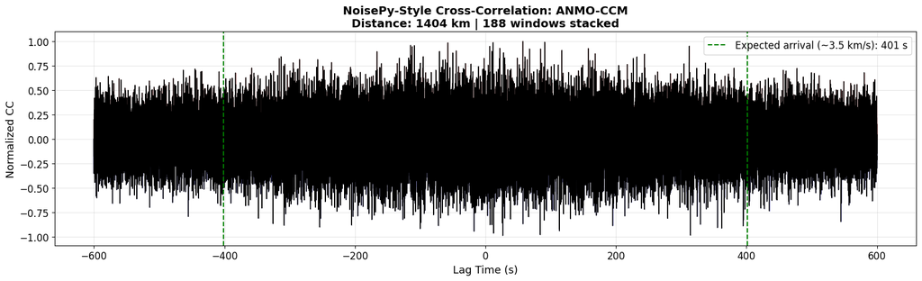

# Module 16: Applications and Case Studies

## 15.1 Ambient Noise Tomography (ANT)

The primary application of ambient noise cross-correlations is **surface wave tomography**. The workflow (Shapiro & Campillo, 2004; Bensen et al., 2007):

1. Compute cross-correlations for **all station pairs**
2. Measure **dispersion curves** (group/phase velocity vs. period)
3. Invert for **velocity maps** at each period
4. Invert velocity maps for **3D velocity structure**

### 15.1.1 Continental-Scale: United States (Bensen et al., 2008)

**Bensen et al. (2008)** produced the first broadband ambient noise tomography of the contiguous US:

- **203 broadband stations**, 24 months of data (2003-2005)
- Both **Rayleigh (Z-Z, R-R)** and **Love (T-T)** waves extracted
- Group and phase velocity maps from **8 to 70 s** period
- Resolution better than **100 km** across most of the US

Key geological features revealed:

- **East-west velocity dichotomy** between the stable craton (fast) and tectonically active west (slow)
- **Sedimentary basins** (Gulf of Mexico, Anadarko, Williston) as slow anomalies at short periods
- **Yellowstone plume** as a strong low-velocity anomaly at 40 s period
- **Moho depth variations** mapped through the transition from crustal to mantle sensitivity

### 15.1.2 Dense Array: Groningen Gas Field (Chmiel et al., 2019)

**Chmiel et al. (2019)** deployed ~400 stations at ~350 m spacing:

- Resolved 3D S-wave velocity to **1 km depth** above the Groningen gas field
- **Joint inversion** of Love and Rayleigh waves (fundamental mode + 1st higher mode)
- Identified geological structures including the Brussel sands and a palaeochannel, **validated against boreholes**

### 15.1.3 Volcanic Island: La Palma (Cabrera-Pérez et al., 2023)

**Cabrera-Pérez et al. (2023)** applied ANT to La Palma (Canary Islands):

- **44 broadband stations** deployed 2018-2020
- **415 valid dispersion curves** extracted, periods 0.35-3.2 s
- Preprocessing: one-bit temporal normalization, spectral whitening, ZZ cross-correlations
- **MANgOSTA nonlinear multiscale inversion** accounting for island topography
- Transdimensional Bayesian depth inversion (no subjective regularization)

Key findings:

- **H1**: High-velocity anomaly (+20-40%) — ancient basal complex plutonic intrusion (4.0-3.0 Ma)
- **L1**: Low-velocity anomaly (-20 to -40%) on western Cumbre Vieja — active hydrothermal system; **dv/v decrease observed before the 2021 Tajogaite eruption** — ascending hydrothermal fluids
- **L2**: Eastern flank — fossil hydrothermal alteration zone
- **L3**: Near San Antonio/Teneguía volcanoes — highly fractured rocks with geothermal activity

> *The pre-eruptive velocity decrease in L1 provides evidence that ANT can detect fluid migration precursory to eruption.* — Cabrera-Pérez et al. (2023)

## 15.2 Velocity Monitoring (dv/v)

### Noise Source Effects on Monitoring (Stehly et al., 2024)

- Non-stationary noise sources introduce systematic errors into dv/v measurements
- Mediterranean stations near Adriatic/Aegean sources are most affected
- Stationarity coefficient (SC) should be monitored; SC < 0.94 indicates problematic non-stationarity

## 15.3 Mineral Exploration with LARGE-N Arrays (Ryberg et al., 2022)

**Ryberg et al. (2022)** demonstrated ANT for mineral exploration in the Erzgebirge, Germany:

- **400 nodal stations** at ~70 m spacing over 1.0 × 1.7 km area
- 10 days of continuous recording
- **Transdimensional Bayesian McMC inversion** — no subjective regularization
- Combined with airborne electromagnetic (EM) data via **K-means clustering**

Key result: Cluster 8 spatially coincides with known greisen (tin-tungsten) mineralization — characterized by **low Vs (~2.4 km/s) and low resistivity (~3.8 Ω·m)** — demonstrating that non-invasive passive seismic can detect ore-forming systems.

## 15.4 Geothermal Exploration

### Geneva Basin (Planès et al., 2020)

- ANT applied in urban/industrial noise environment
- Imaged subsurface velocity structure of a Cenozoic sedimentary basin
- Identified low-velocity zones consistent with Mesozoic sequences
- Provided constraints on basin geometry for deep geothermal well planning

### La Palma Resource Assessment (Fariña-González et al., 2025)

Building on the ANT results of Cabrera-Pérez et al. (2023):

- Total geothermal potential: **~17 MWe** at 90% confidence
- LCOE = **0.099 $/kWh** vs. diesel 0.352 $/kWh
- Demonstrates integration of geophysical imaging with resource economics

## 15.5 Summary: When to Use What

| Method | Scale | Depth | Stations | Duration | Application |
| --- | --- | --- | --- | --- | --- |
| HVSR | Point | 10-500 m | 1 | ~30 min | Site characterization |
| ANT (dense array) | 1-10 km | 0-1 km | 100-1000 | 1-30 days | Near-surface imaging |
| ANT (regional) | 100-1000 km | 0-200 km | 10-200 | 3-24 months | Crustal structure |
| dv/v monitoring | Station pair | Crust | 5-50 | Continuous | Volcanic/fault monitoring |
| SPAC | 100 m | 10-100 m | 5-20 | ~1 hour | Shallow Vs profiling |

```
Downloading data from multiple stations...
  ANMO: 1728000 samples, (34.95, -106.46)
  HRV: 864000 samples, (42.51, -71.56)
  CCM: 1728000 samples, (38.06, -91.24)

3 stations → 3 station pairs
  Processing ANMO-HRV (distance: 3124 km)...
  Processing ANMO-CCM (distance: 1404 km)...
  Processing HRV-CCM (distance: 1741 km)...

All pairs processed!
```

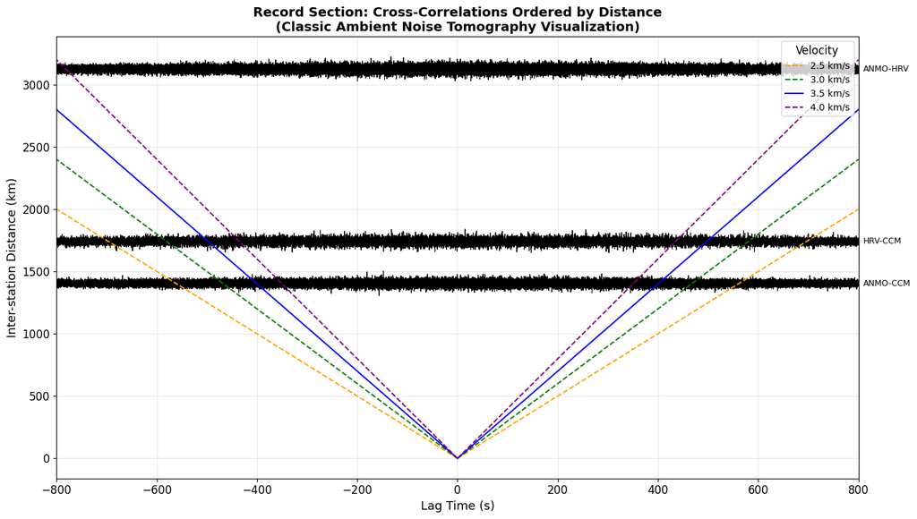

[output not shown]

# Module 17: Dense Arrays, Advanced Topics, and Exercises

## 16.1 LARGE-N Arrays for Near-Surface Imaging

The advent of **low-cost nodal seismometers** (e.g., DIGOS CUBE, SmartSolo, Zland) has enabled the deployment of hundreds to thousands of sensors in dense arrays (Ryberg et al., 2022).

### Key Advantages

- **Station spacing of 10-350 m** resolves shallow structures (< 1 km)
- **Short deployments (1-30 days)** are sufficient for surface wave extraction
- **No active source needed** — purely passive acquisition
- **Higher-mode surface waves** can be extracted from dense arrays (Chmiel et al., 2019)

### Processing Considerations for Dense Arrays

- **One-bit normalization** is usually sufficient for short-period noise (< 1 s)
- **Spectral whitening** is critical to broaden frequency content
- **All station pairs** are computed: $N(N-1)/2$ pairs for $N$ stations
- **Phase velocity** (rather than group velocity) is preferred for dense arrays — higher resolution

### SPAC Method (Spatial Autocorrelation)

The SPAC method (Aki, 1957) uses **circular or triangular arrays** to extract phase velocity dispersion from the spatial coherence of ambient noise:

$$\rho(r, \omega) = J_0\left(\frac{\omega r}{c(\omega)}\right) \qquad [\text{Aki, 1957}]$$

This is mathematically equivalent to the zero-lag azimuthal average of cross-correlations and is particularly useful for **shallow Vs profiling** (Hunter & Crow, 2015).

## 16.2 Body Wave Extraction from Ambient Noise

While ambient noise is dominated by surface waves, **body waves** (P, S) can also be extracted under certain conditions:

- Very long stacking times (> 1 year)
- Dense arrays with good azimuthal coverage
- Higher frequencies where body-wave noise sources exist
- **Autocorrelation** (single-station) can extract reflected body waves (Claerbout, 1968)

## 16.3 Exercises

### Exercise 1: Effect of Preprocessing Parameters

- Download 1 month of data for a station pair
- Vary the temporal normalization method (none, one-bit, RAM) and spectral whitening bandwidth
- Compare the resulting cross-correlations — which combination gives the highest SNR?
- Discuss in terms of Fichtner et al. (2020) optimal processing framework

### Exercise 2: Convergence Analysis

- Stack cross-correlations for increasing durations: 1 day, 1 week, 2 weeks, 1 month, 3 months
- Measure SNR as a function of stacking duration
- Compare with the theoretical $\text{SNR} \propto t^{1/n}$ relation from Bensen et al. (2007)
- At what duration does the cross-correlation stabilize?

### Exercise 3: Mini-Tomography

- Select 10-20 stations in a region of interest
- Compute all-pairs cross-correlations (1 month of data)
- Measure group velocity dispersion curves via FTAN
- Apply data selection criteria (Bensen et al., 2007): $\Delta > 3\lambda$, SNR > 10
- Produce a 2D group velocity map at a target period

### Exercise 4: dv/v Monitoring

- Select a station pair near a volcanic or fault zone
- Compute daily cross-correlations for 6-12 months
- Measure dv/v using the stretching technique
- Identify seasonal patterns and any tectonic/volcanic signals
- Correct for environmental effects (temperature, rainfall)

### Exercise 5: HVSR Site Survey

- Deploy a 3-component seismometer at 3-5 sites with different geological conditions
- Use 30-60 min of ambient noise at each site
- Compute HVSR using the Cox et al. (2020) lognormal statistics
- Map the resonance frequency and interpret in terms of local geology

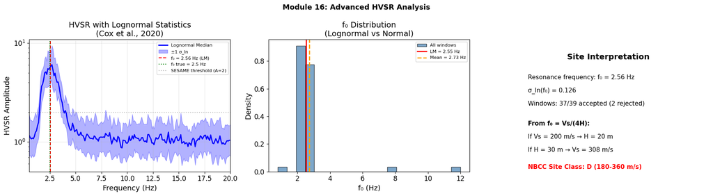

```
Key points (Cox et al., 2020):
• f₀ follows a LOGNORMAL distribution — use LM, not arithmetic mean
• The window-rejection algorithm removes outliers in log space
• Report: LM_f₀ ± σ_ln(f₀), NOT mean ± std
• Software: hvsrpy Python package implements this algorithm
```

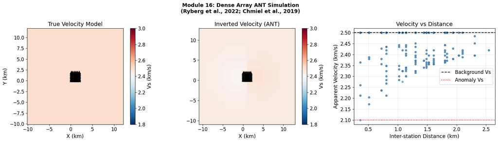

```
Dense array: 36 stations, 630 pairs
Station spacing: ~0.36 km
Max pair distance: 2.55 km

Key insight: Dense arrays with short inter-station distances
resolve shallow velocity anomalies that regional networks miss.
This is the basis for LARGE-N exploration surveys (Ryberg et al., 2022).
```

# Summary and Key Takeaways

## What We Covered

### Theory

1. **Ambient Noise**: The Earth is continuously vibrating due to ocean-atmosphere interactions (microseisms) and anthropogenic sources. The noise field's stationarity is critical for reliable measurements (Stehly et al., 2024).
2. **Cross-Correlation Theorem**: $C_{AB}(\omega) = U_A^*(\omega) U_B(\omega)$ — the cross-correlation of two signals equals the conjugate multiplication of their Fourier transforms (Campillo & Roux, 2015).
3. **Green's Function Retrieval**: $\langle u_1(\omega) u_2^*(\omega) \rangle \propto \text{Im}[G(\vec{r}_1, \vec{r}_2; \omega)]$ — the cross-correlation of ambient noise converges to the Green's function (Lobkis & Weaver, 2001; Campillo & Paul, 2003).
4. **Preprocessing**: Temporal normalization (one-bit, RAM) + spectral whitening broaden the frequency content and suppress earthquakes (Bensen et al., 2007). Standard processing introduces biases quantifiable via the transfer coefficient framework (Fichtner et al., 2020).
5. **Seismic Interferometry**: The broader framework for extracting deterministic information from wave interference (Wapenaar, 2004; Snieder, 2004).
6. **Tomographic Inversion**: From dispersion curves to 2D velocity maps via penalized least-squares (Bensen et al., 2008), and from maps to 3D Vs structure via depth inversion (Rawlinson et al., 2010; Cabrera-Pérez et al., 2023).
7. **Velocity Monitoring**: $\delta v/v$ tracked with $10^{-5}$ precision using coda of noise correlations (Sens-Schoenfelder & Wegler, 2006; Brenguier et al., 2016).
8. **HVSR**: Single-station site characterization; $f_0$ follows a lognormal distribution (Cox et al., 2020).

### Practice

1. **ObsPy** for data retrieval, processing, and instrument response removal
2. **Preprocessing** following Bensen et al. (2007): temporal normalization + spectral whitening
3. **Cross-correlation computation** using frequency-domain methods
4. **Stacking methods**: linear, PWS, robust
5. **Optimal processing** analysis following Fichtner et al. (2020)
6. **Dispersion analysis**: FTAN for group velocity measurement
7. **2D tomographic inversion** with regularization
8. **dv/v measurement**: Stretching technique
9. **HVSR with lognormal statistics** following Cox et al. (2020)
10. **Dense array simulation** for near-surface imaging

## Complete Reference List

- Aki, K. (1957). Space and time spectra of stationary stochastic waves. *Bull. Earthquake Res. Inst.*, 35, 415-457.
- Bensen, G.D. et al. (2007). Processing seismic ambient noise data to obtain reliable broad-band surface wave dispersion measurements. *GJI*, 169, 1239-1260.
- Bensen, G.D. et al. (2008). Broadband ambient noise surface wave tomography across the United States. *JGR*, 113, B05306.
- Beyreuther, M. et al. (2010). ObsPy: A Python Toolbox for Seismology. *SRL*, 81(3), 530-533.
- Brenguier, F. et al. (2016). 4-D noise-based seismology at volcanoes. *JVGR*, 321, 182-195.
- Cabrera-Pérez, I. et al. (2021). A nonlinear multiscale inversion approach for ambient noise tomography. *GJI*, 225, 1158-1173.
- Cabrera-Pérez, I. et al. (2023). Geothermal and structural features of La Palma island imaged by ANT. *Sci. Rep.*, 13, 12892.
- Campillo, M. & Paul, A. (2003). Long-range correlations in the diffuse seismic coda. *Science*, 299, 547-549.
- Campillo, M. & Roux, P. (2015). Seismic Imaging and Monitoring with Ambient Noise Correlations. *Treatise on Geophysics*, 2nd ed., Vol. 1, 391-417.
- Chmiel, M. et al. (2019). Ambient noise multimode Rayleigh and Love wave tomography, Groningen. *GJI*, 218, 1781-1795.
- Claerbout, J.F. (1968). Synthesis of a layered medium from its acoustic transmission response. *Geophysics*, 33, 264-269.
- Cox, B.R. et al. (2020). A statistical representation and frequency-domain window-rejection algorithm for HVSR. *GJI*, 221(3), 2170-2183.
- Fichtner, A. et al. (2017). Generalised interferometry I: Theory for inter-station correlations. *GJI*, 208, 603-638.
- Fichtner, A. et al. (2020). Optimal processing for seismic noise correlations. *GJI*, 223, 1548-1564.
- Hunter, J.A. & Crow, H.L. (2015). Shear Wave Velocity Measurement Guidelines for Canadian Seismic Site Characterization. *Natural Resources Canada*, General Information Product 110e.
- Jiang, C. & Denolle, M.A. (2020). NoisePy: A New High-Performance Python Tool for Ambient-Noise Seismology. *SRL*, 91(3), 1853-1866.
- Lobkis, O.I. & Weaver, R.L. (2001). On the emergence of the Green's function in the correlations of a diffuse field. *JASA*, 110(6), 3011-3017.
- Molnar, S. et al. (2022). A review of the microtremor HVSR method. *J. Seismol.*, 26, 653-685.
- Nakata, N., Gualtieri, L. & Fichtner, A. (2019). *Seismic Ambient Noise*. Cambridge University Press.
- Pavlis, G.L. & Vernon, F.L. (2010). Array processing of teleseismic body waves with the USArray. *CAGEO*, 36, 910-920.
- Planès, T. et al. (2020). Ambient-noise tomography of the Greater Geneva Basin. *GJI*, 220(1), 370-383.
- Rawlinson, N. et al. (2010). Seismic tomography: A window into deep Earth. *Phys. Earth Planet. Inter.*, 178, 101-135.
- Ryberg, T. et al. (2022). Ambient seismic noise analysis of LARGE-N data for mineral exploration, Erzgebirge. *Solid Earth*, 13, 519-533.
- Schimmel, M. & Paulssen, H. (1997). Noise reduction and detection of weak, coherent signals through phase-weighted stacks. *GJI*, 130, 497-505.
- Sens-Schoenfelder, C. & Wegler, U. (2006). Passive image interferometry and seasonal variations at Merapi Volcano. *GRL*, 33, L21302.
- Shapiro, N.M. & Campillo, M. (2004). Emergence of broadband Rayleigh waves from correlations of the ambient seismic noise. *GRL*, 31, L07614.
- Shearer, P.M. (2019). *Introduction to Seismology*, 3rd ed. Cambridge University Press.
- Snieder, R. (2004). Extracting the Green's function from the correlation of coda waves. *Phys. Rev. E*, 69, 046610.
- Stehly, L. et al. (2024). Dynamic of seismic noise sources in the Mediterranean Sea. *C. R. Géoscience*, doi:10.5802/crgeos.241.
- Wapenaar, K. (2004). Retrieving the elastodynamic Green's function by cross correlation. *PRL*, 93, 254301.

```
======================================================================
  AMBIENT NOISE SEISMOLOGY - COURSE SUMMARY
======================================================================

Key equations implemented in this notebook:

1. Cross-Correlation Theorem:
   C_AB(f) = U_A*(f) . U_B(f)
   [Campillo & Roux, 2015, Eq. 2; Jiang & Denolle, 2020, Eq. 1]

2. Green's Function from Noise:
   <u1(w) u2*(w)> = -4|F(w)|^2 Im[G(r1, r2; w)]
   [Campillo & Roux, 2015, Eq. 7]

3. Spatial Correlation (Diffuse Field):
   C(w) = |F(w)|^2 J_0(k|r1 - r2|)
   [Aki, 1957; Campillo & Roux, 2015, Eq. 5]

4. Running-Absolute-Mean Normalization:
   w_n = (1/(2N+1)) * sum(|d_j|, j=n-N..n+N)
   [Bensen et al., 2007, Eq. 1]

5. Velocity Change (Stretching):
   dv/v = -dt/t = epsilon_0
   [Sens-Schoenfelder & Wegler, 2006]

6. MHVSR:
   HVSR = sqrt((E1 + E2) / E3)
   [Molnar et al., 2022]

7. Site Resonance:
   f_n = (2n+1) * Vs / (4h)
   [Molnar et al., 2022]

======================================================================
  Software: ObsPy (Beyreuther et al., 2010)
           NoisePy (Jiang & Denolle, 2020)
======================================================================
```